# Whole-genome sequencing reveals distinct mutational mechanisms shaping endometrial cancer

Tongwu Zhang

2026-02-09

## 1 Overview

This R Markdown document reproduces the main analyses and figures for TCGA-UCEC WGS dataset

Manuscript title: Whole-genome sequencing reveals distinct mutational mechanisms shaping endometrial cancer

## 2 Fig. 4: Indel mutational signatures distinguish UCEC molecular subtypes.

## 3 Load Required Libraries and Set Plotting Styles

(You may need to install some packages if missing)

```r
source("./Rcode/ztw_function.R")
source('./Rcode/Sherlock_functions.R')
source("./Rcode/ztw.R")
library(rstatix)
library(scales)
library(ggpubr)
library(hrbrthemes)
```

## 4 Fig.4a

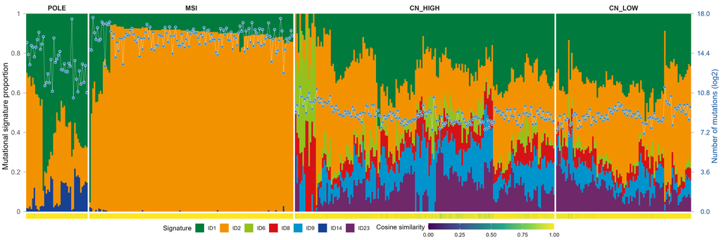

```r
# Mutational signature landscape ------------------------------------------
load('./Rdata/ucec_mutational_signatures.RData',verbose = T)
load('./Rdata/wgsdata.RData',verbose = T)
load('./Rdata/ucec_subtype_data.RData',verbose = T)

# Mutational signature landscape ID ------------------------------------------
plot_mutational_signature_landscape(
  tumor_activity_all = ucec_activity_all %>% select(Tumor_Barcode,starts_with('ID')),
  tumor_activity_all_ratio = ucec_activity_all_ratio %>% select(Tumor_Barcode,starts_with('ID')),
  tumor_decompsite = ucec_id83_decompsite,
  sigcol = sigcol_id,
  group_data = subtype_data %>% select(Tumor_Barcode,Subtype),
  sortby_signatures = NULL,
  sortby_cutoff = 0.1 ,
  #samlevs = sbs_landscape$samlevs,
  output_file = './Rscripts/Figures/Fig4a.png'
)
```

#Fig.4a,ID mutational signature decomposition across UCEC tumors, ordered by molecular subtype. Stacked bars show the relative contribution of each ID signature per tumor (left axis), with total ID mutation counts shown as a line plot (right axis). Cosine similarities between the original and reconstructed ID profiles are shown below.

## 5 Fig.4b

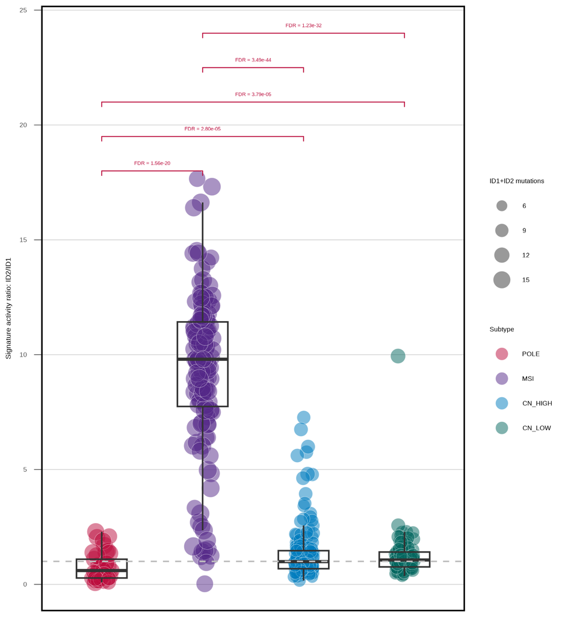

```r
# By Subtype --------------------------------------------------------------
maxsigdata <- ucec_activity_all %>% select(Tumor_Barcode,starts_with('SBS')) %>% pivot_longer(-Tumor_Barcode) %>% group_by(Tumor_Barcode) %>% arrange(desc(value)) %>% slice(1) %>% ungroup()
ucec_activity_all %>% filter(ID1==0|ID2==0) ## 6 samples

tdata <- ucec_activity_all %>%
  left_join(maxsigdata) %>%
  filter(ID1>0,ID2>0) %>%
  mutate(Ratio=((ID2)/(ID1)),ID1_ID2=ID1+ID2) %>%
  mutate(Group=if_else(SBS44<50,'No SBS44',if_else(name=='SBS44','SBS44 dominant','SBS44 non-dominant' ))) %>%
  select(Tumor_Barcode,SBS44,ID1_ID2,Ratio,Group) %>%
  mutate(Group=factor(Group, levels = c('No SBS44','SBS44 non-dominant','SBS44 dominant')))


tdata <- tdata %>% left_join(subtype_data)

stat.test <- tdata %>%
  pairwise_wilcox_test(Ratio ~ Subtype, p.adjust.method = "BH") %>%
  add_xy_position(x = "Subtype") %>%
  #mutate(p.label = p_format(p.adj, digits = 2, add.p = TRUE))  # e.g., "p = 0.003"
  mutate(p.label = if_else(p.adj<0.001,sprintf("FDR = %.2e",p.adj),sprintf("FDR = %.2f",p.adj))) %>%
  mutate(col=if_else(p.adj<0.05,ncicolpal[1],'black'))

stat.test$y.position <- c(20,20.5,21,21.5,22,22.5)-2

tdata %>%
  mutate(Ratio = if_else(Ratio>20,20,Ratio)) %>%
  ggplot(aes(Subtype, Ratio, fill = Subtype)) +
  # jittered points inside boxes, size by SBS44
  geom_point(aes(size = log2(ID1_ID2+1)),
             position = position_jitter(width = 0.1, height = 0, seed = 1),
             shape = 21, color = "white", alpha = 0.5,stroke=0.2) +
  geom_boxplot(width = 0.5, fill = NA, color = "gray20",
               outlier.shape = NA) +
  geom_hline(yintercept = 1,linetype = 2,col='gray',size=0.5)+
  # p-values
  stat_pvalue_manual(stat.test, label = "p.label", col=ncicolpal[1],
                     tip.length = 0.01, step.increase = 0.05, hide.ns = TRUE) +
  labs(x = NULL, y = 'Signature activity ratio: ID2/ID1', size = "ID1+ID2 mutations") +
  scale_fill_manual(values = subtype_color) +
  scale_size_area() +
  scale_y_continuous(breaks = scales::pretty_breaks(n = 7)) +
  theme_ipsum_rc(axis_text_size = 14, axis_title_just = 'm',
                 axis_title_size = 16, grid = 'Y', ticks = TRUE) +
  panel_border(color = 'black') +
  theme(axis.text.x = element_blank(),
        panel.spacing.x = unit(0.4, 'cm'),
        axis.ticks.x = element_blank(),
        plot.margin = margin(4, 4, 4, 4),
        legend.position = 'right',
        legend.text = element_text(size = 14),
        legend.title = element_text(size = 14),
        strip.text.x = element_text(hjust = 0.5, face = 'bold', size = 16)) +
  guides(fill=guide_legend(override.aes = list(size=4)),size=guide_legend(override.aes = list(fill='gray20')))
#ylim(c(0,50))
ggsave(filename = './Rscripts/Figures/Fig4b.png',width = 5.5,height = 6)# separated by Group
```

#Fig.4b,Comparison of ID2-to-ID1 signature activity ratios across UCEC molecular subtypes. Each point represents an individual tumor. Boxplots indicate the median and interquartile range. Statistical significance was assessed using two-sided Wilcoxon rank-sum tests with FDR correction.

## 6 Fig.4c

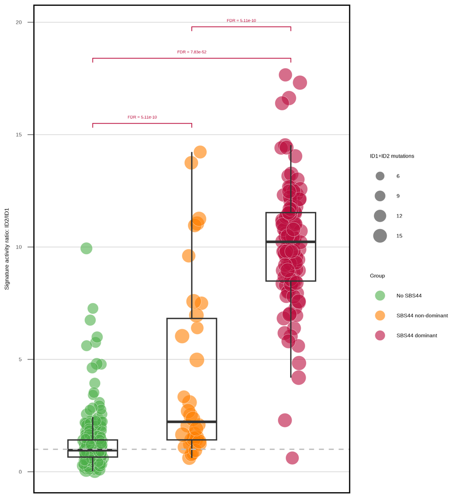

```r
# ID1 and ID2 Ratio -------------------------------------------------------
library(rstatix)

ucec_activity_all %>% filter(ID1==0|ID2==0) ## 6 samples

tdata <- ucec_activity_all %>%
  left_join(maxsigdata) %>%
  filter(ID1>0,ID2>0) %>%
  mutate(Ratio=((ID2)/(ID1)),ID1_ID2=ID1+ID2) %>%
  mutate(Group=if_else(SBS44<50,'No SBS44',if_else(name=='SBS44','SBS44 dominant','SBS44 non-dominant' ))) %>%
  select(Tumor_Barcode,SBS44,ID1_ID2,Ratio,Group) %>%
  mutate(Group=factor(Group, levels = c('No SBS44','SBS44 non-dominant','SBS44 dominant')))

stat.test <- tdata %>%
  pairwise_wilcox_test(Ratio ~ Group, p.adjust.method = "BH") %>%
  add_xy_position(x = "Group") %>%
  #mutate(p.label = p_format(p.adj, digits = 2, add.p = TRUE))  # e.g., "p = 0.003"
  mutate(p.label = if_else(p.adj<0.001,sprintf("FDR = %.2e",p.adj),sprintf("FDR = %.2f",p.adj))) %>%
  mutate(col=if_else(p.adj<0.05,ncicolpal[1],'black'))

stat.test$y.position <- c(15.5,17.5,18)


tdata %>%
  ggplot(aes(Group, Ratio, fill = Group)) +
  # jittered points inside boxes, size by SBS44
  geom_point(aes(size = log2(ID1_ID2+1)),
             position = position_jitter(width = 0.1, height = 0, seed = 1),
             shape = 21, color = "white", alpha = 0.6,stroke=0.2) +
  geom_boxplot(width = 0.5, fill = NA, color = "gray20",
               outlier.shape = NA) +
  geom_hline(yintercept = 1,linetype = 2,col='gray',size=0.5)+
  # p-values
  stat_pvalue_manual(stat.test, label = "p.label", col=ncicolpal[1],
                     tip.length = 0.01, step.increase = 0.05, hide.ns = TRUE) +
  labs(x = NULL, y = 'Signature activity ratio: ID2/ID1', size = "ID1+ID2 mutations") +
  scale_fill_manual(values = ncicolpal[c(3:1)]) +
  scale_size_area(max_size = 6) +
  scale_y_continuous(breaks = scales::pretty_breaks(n = 7)) +
  theme_ipsum_rc(axis_text_size = 14, axis_title_just = 'm',
                 axis_title_size = 16, grid = 'Y', ticks = TRUE) +
  panel_border(color = 'black') +
  theme(axis.text.x = element_blank(),
        panel.spacing.x = unit(0.4, 'cm'),
        axis.ticks.x = element_blank(),
        plot.margin = margin(4, 4, 4, 4),
        legend.position = 'right',
        legend.text = element_text(size = 14),
        legend.title = element_text(size = 14),
        strip.text.x = element_text(hjust = 0.5, face = 'bold', size = 16)) +
  guides(fill=guide_legend(override.aes = list(size=4)),size=guide_legend(override.aes = list(fill='gray20')))
#ylim(c(0,50))

ggsave(filename = './Rscripts/Figures/Fig4c.png',width = 5.5,height = 6)
```

## 7 Fig.4d

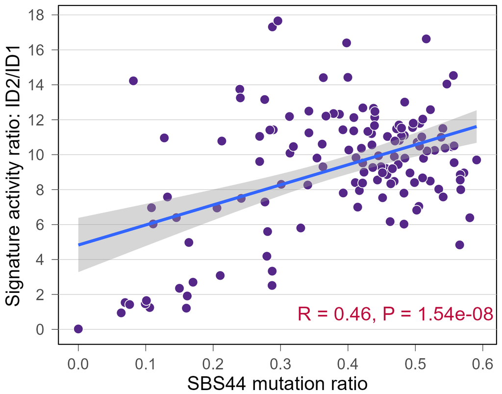

```r
tdata <- tdata %>% left_join(subtype_data)
stat.test <- tdata %>%
  pairwise_wilcox_test(Ratio ~ Subtype, p.adjust.method = "BH") %>%
  add_xy_position(x = "Subtype") %>%
  #mutate(p.label = p_format(p.adj, digits = 2, add.p = TRUE))  # e.g., "p = 0.003"
  mutate(p.label = if_else(p.adj<0.001,sprintf("FDR = %.2e",p.adj),sprintf("FDR = %.2f",p.adj))) %>%
  mutate(col=if_else(p.adj<0.05,ncicolpal[1],'black'))

stat.test$y.position <- c(20,20.5,21,21.5,22,22.5)-2

tdata=tdata %>%
  mutate(Ratio = if_else(Ratio>20,20,Ratio))

tdata2 <- tdata %>%
  filter(Subtype == 'MSI') %>%
  left_join(
    ucec_activity_all_ratio %>% mutate(MSI_Signature=SBS44+SBS54+SBS15+SBS21) %>%  select(Tumor_Barcode,SBS44_Ratio=SBS44,MSI_Signature)
  )


plot_scatter(
  data = tdata2,
  x = SBS44_Ratio, y = Ratio,
  #group = name,
  #facet = TRUE, facet_scales = "free", palette = ncicolpal[1],
  point_color = "white",
  point_fill = "#542788",
  x_lab = "SBS44 mutation ratio", y_lab = "Signature activity ratio: ID2/ID1",
  label_x_rel = 0.55,
  label_y_rel=0.05,               # one per facet (recycled if lengths differ)
  alpha_sig = 0.05,
  #label_override = ("β = 0.01, P = 6.70e-04"),
  #label_color_override = ncicolpal[1]
  # p_override = c(GroupA = 0.012, GroupB = 0.18),  # optional override by group
  #add_reg_eq = FALSE                      # set TRUE to show the equation
)

ggsave(filename = './Rscripts/Figures/Fig4d.png',width = 4.5,height = 4)
```

## 8 Fig.4f

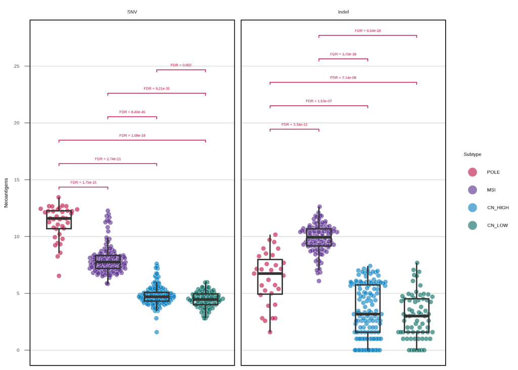

```r
# Neoantigene -------------------------------------------------------------

tdata <- read_delim('./Jian/UCEC_Neoaantigen_Only.txt',delim = '\t',col_names = T)

tdata <- tdata %>%
  left_join(subtype_data %>% select(Subject,Subtype)) %>%
  filter(!is.na(Subtype)) %>%
  filter(!is.na(Alteration)) %>%
  mutate(Alteration = log2(Alteration+1)) %>%
  mutate(Gene = str_remove(Gene,'Neoantigens')) %>%
  mutate(Gene=fct_rev(Gene))

res_burden2 <- plot_group_compare(
  tdata       = tdata,
  value       = Alteration,
  group       = "Subtype",
  facet =     "Gene",
  FDR_facet = T,
  facet_ncol = 2,
  ylab        = "Neoantigens",
  hide_ns    = T,
  palette     = subtype_color,
  pcol_sig    = ncicolpal[1],
  #facet_scales = 'free_y',
  output_file = "./Rscripts/Figures/fig4f.png",
  #y_pos_adjust = c(3,60,7,5),
  width       = 7,
  height      = 5,
  p_off = F
)
```